# Red Wine Quality Exploration by Layali R.

> This dataset is about Red Wine components. The goal is to identify the main components of wine, the relationships between these components and develop an idea about what distinguishes good from bad wine.

# General analysis

> Please note that below I combined the bivariate and multivariate plot sections because they are tightly connected, I found that a story will be told better if I immediately followed a bivariate plot with a related multivariate plot.

```
## [1] 1599   13
```

```
## 'data.frame':    1599 obs. of  13 variables:
##  $ X                   : int  1 2 3 4 5 6 7 8 9 10 ...
##  $ fixed.acidity       : num  7.4 7.8 7.8 11.2 7.4 7.4 7.9 7.3 7.8 7.5 ...
##  $ volatile.acidity    : num  0.7 0.88 0.76 0.28 0.7 0.66 0.6 0.65 0.58 0.5 ...
##  $ citric.acid         : num  0 0 0.04 0.56 0 0 0.06 0 0.02 0.36 ...
##  $ residual.sugar      : num  1.9 2.6 2.3 1.9 1.9 1.8 1.6 1.2 2 6.1 ...
##  $ chlorides           : num  0.076 0.098 0.092 0.075 0.076 0.075 0.069 0.065 0.073 0.071 ...
##  $ free.sulfur.dioxide : num  11 25 15 17 11 13 15 15 9 17 ...
##  $ total.sulfur.dioxide: num  34 67 54 60 34 40 59 21 18 102 ...
##  $ density             : num  0.998 0.997 0.997 0.998 0.998 ...
##  $ pH                  : num  3.51 3.2 3.26 3.16 3.51 3.51 3.3 3.39 3.36 3.35 ...
##  $ sulphates           : num  0.56 0.68 0.65 0.58 0.56 0.56 0.46 0.47 0.57 0.8 ...
##  $ alcohol             : num  9.4 9.8 9.8 9.8 9.4 9.4 9.4 10 9.5 10.5 ...
##  $ quality             : int  5 5 5 6 5 5 5 7 7 5 ...
```

```
##        X          fixed.acidity   volatile.acidity  citric.acid
##  Min.   :   1.0   Min.   : 4.60   Min.   :0.1200   Min.   :0.000
##  1st Qu.: 400.5   1st Qu.: 7.10   1st Qu.:0.3900   1st Qu.:0.090
##  Median : 800.0   Median : 7.90   Median :0.5200   Median :0.260
##  Mean   : 800.0   Mean   : 8.32   Mean   :0.5278   Mean   :0.271
##  3rd Qu.:1199.5   3rd Qu.: 9.20   3rd Qu.:0.6400   3rd Qu.:0.420
##  Max.   :1599.0   Max.   :15.90   Max.   :1.5800   Max.   :1.000
##  residual.sugar     chlorides       free.sulfur.dioxide
##  Min.   : 0.900   Min.   :0.01200   Min.   : 1.00
##  1st Qu.: 1.900   1st Qu.:0.07000   1st Qu.: 7.00
##  Median : 2.200   Median :0.07900   Median :14.00
##  Mean   : 2.539   Mean   :0.08747   Mean   :15.87
##  3rd Qu.: 2.600   3rd Qu.:0.09000   3rd Qu.:21.00
##  Max.   :15.500   Max.   :0.61100   Max.   :72.00
##  total.sulfur.dioxide    density             pH          sulphates
##  Min.   :  6.00       Min.   :0.9901   Min.   :2.740   Min.   :0.3300
##  1st Qu.: 22.00       1st Qu.:0.9956   1st Qu.:3.210   1st Qu.:0.5500
##  Median : 38.00       Median :0.9968   Median :3.310   Median :0.6200
##  Mean   : 46.47       Mean   :0.9967   Mean   :3.311   Mean   :0.6581
##  3rd Qu.: 62.00       3rd Qu.:0.9978   3rd Qu.:3.400   3rd Qu.:0.7300
##  Max.   :289.00       Max.   :1.0037   Max.   :4.010   Max.   :2.0000
##     alcohol         quality
##  Min.   : 8.40   Min.   :3.000
##  1st Qu.: 9.50   1st Qu.:5.000
##  Median :10.20   Median :6.000
##  Mean   :10.42   Mean   :5.636
##  3rd Qu.:11.10   3rd Qu.:6.000
##  Max.   :14.90   Max.   :8.000
```

> Check if there are missing values

```
## [1] "Is there any missing values?"
```

```
## [1] "No"
```

> There are no missing values.

> Check if observations are unique, I will remove the column marking the sequence number for each observations, it is not needed in my EDA

```
## [1] "Are all observations are unique?"
```

```
## [1] "No"
```

> I will add two columns to dataset, total acidity and quality bucket. Later in this report I will describe how I reach the conclusion that total acidity should include citric acid and fixed acidity. Also, quality bucket is going to help in the multivariate analysis.

# Univariate Plots Section

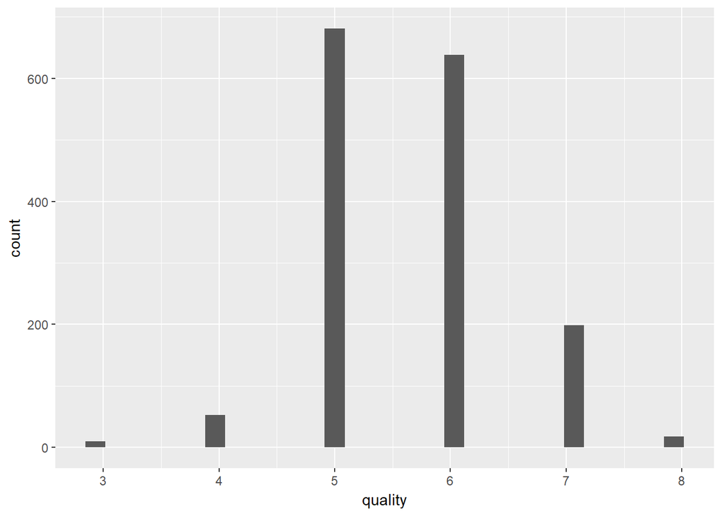

```
##
##   3   4   5   6   7   8
##  10  53 681 638 199  18
```

> The quality of the red wine in this data set ranges between 3 and 8. There is very small number of wine with very low quality of 3 or very high quality of 8. The observations seem to be right skewed with short tail, they center around 5.5.

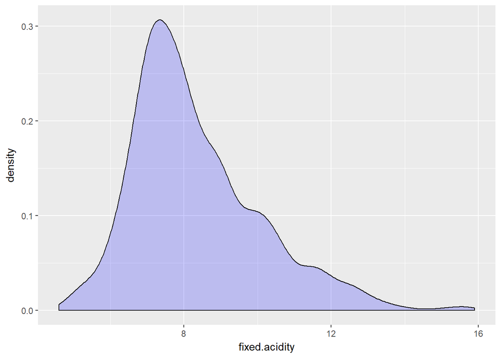

```
##    Min. 1st Qu.  Median    Mean 3rd Qu.    Max.
##    4.60    7.10    7.90    8.32    9.20   15.90
```

> Most of the observations have fixed.acidity of about 7. The distribution is right skewed with a tail expanding until about 16. Too much fixed acidity will result in tartar wine, this explains why there are small number of observations with high amounts of this acid. There are no values of zero or 1 so it should be safe to try the log scale.

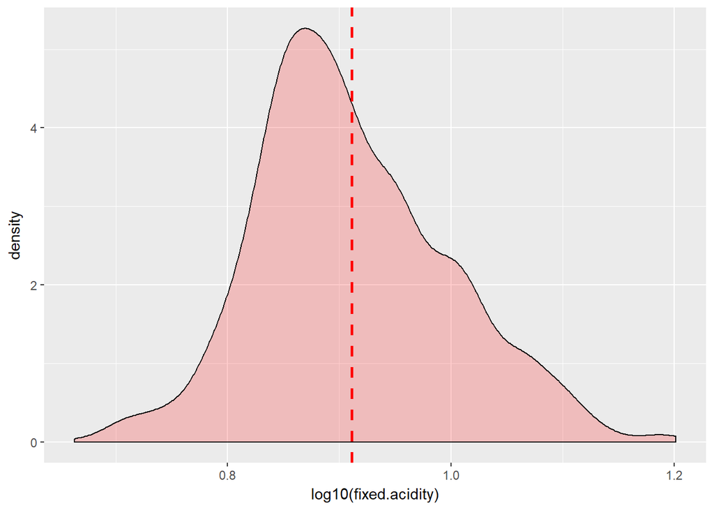

```
##    Min. 1st Qu.  Median    Mean 3rd Qu.    Max.
##  0.6628  0.8513  0.8976  0.9112  0.9638  1.2014
```

> The density plot of the log10 of this variable looks “close” to normal the mean is 0.91 and is represented using the vertical red line, it is not quite at the center because the density is not normal.

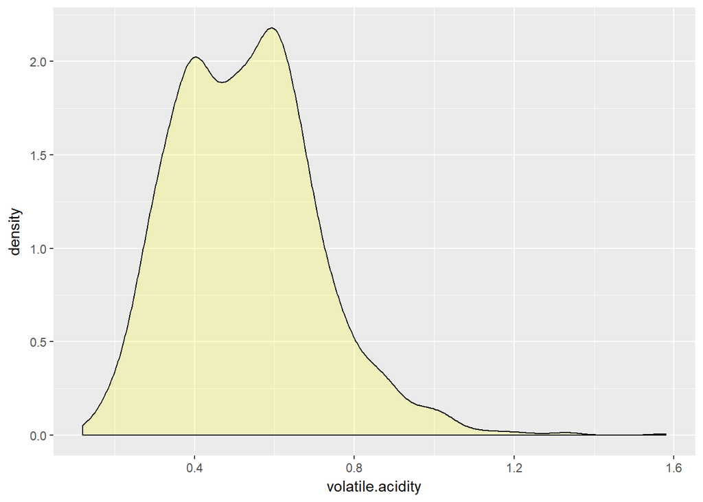

> The density plot is bimodal. Volatile acidity is found in very small amounts in red wine, it appears when wine is steamed. More about this variable later in this report.

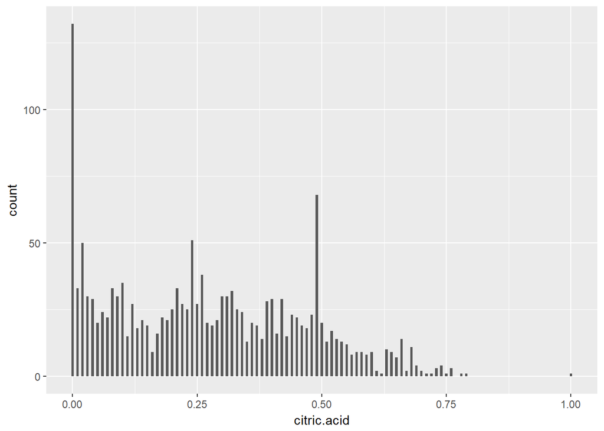

```
##
## 0.62 0.71 0.72 0.75 0.78 0.79    1 0.61 0.67  0.7 0.73 0.76 0.69 0.74 0.65
##    1    1    1    1    1    1    1    2    2    2    3    3    4    4    7
## 0.56 0.59 0.16 0.57 0.58  0.6 0.64 0.63 0.68 0.55 0.35 0.51 0.54 0.38 0.53
##    8    8    9    9    9    9    9   10   11   12   13   13   13   14   14
## 0.66 0.11 0.43 0.17 0.41 0.52 0.13 0.47 0.15 0.28 0.37 0.46 0.05 0.27 0.36
##   14   15   15   16   16   17   18   18   19   19   19   19   20   20   20
##  0.5 0.14 0.19 0.29 0.07 0.18 0.45 0.44 0.48 0.06 0.34  0.2 0.23 0.33 0.12
##   20   21   21   21   22   22   22   23   23   24   24   25   25   25   27
## 0.22 0.25 0.39 0.04  0.4 0.42 0.03 0.09  0.3 0.31 0.32 0.01 0.08 0.21  0.1
##   27   27   28   29   29   29   30   30   30   30   32   33   33   33   35
## 0.26 0.02 0.24 0.49    0
##   38   50   51   68  132
```

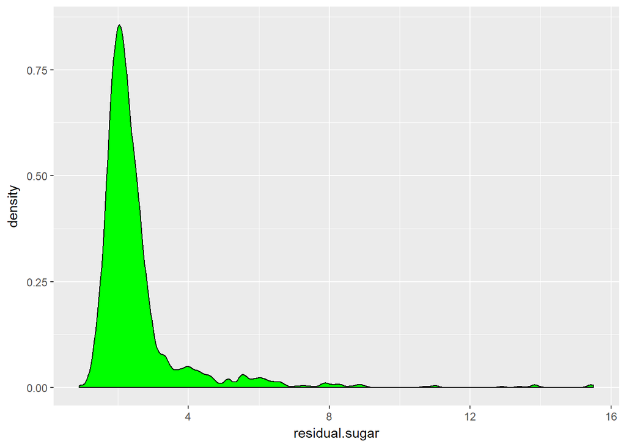

```
##    Min. 1st Qu.  Median    Mean 3rd Qu.    Max.
##   0.900   1.900   2.200   2.539   2.600  15.500
```

> The density looks right skewed with long tail. Even when transformed to log10 (not interesting enough to include in this document), it also looks right skewed. Log10 is not useful because most values are very small. The description document mentions that “wines with greater than 45 grams/liter are considered sweet”. There are no sweet wines in this sample. The maximum value is 15.5.

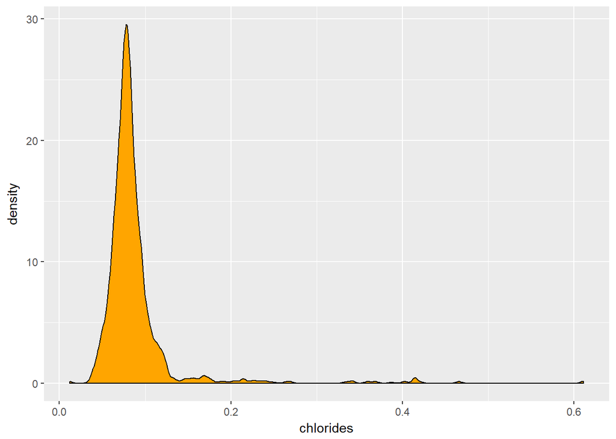

> Similar observations can be seen when plotting the chlorides. Most observations have very small amounts of this compound. It is clearly right skewed. Chlorides are present in wine from materials used to sterilize wine making equipments, detergents are not commonly used to clean the equipments because they leave residue. Based on this reasoning, I don’t think chloride is major component of wine.

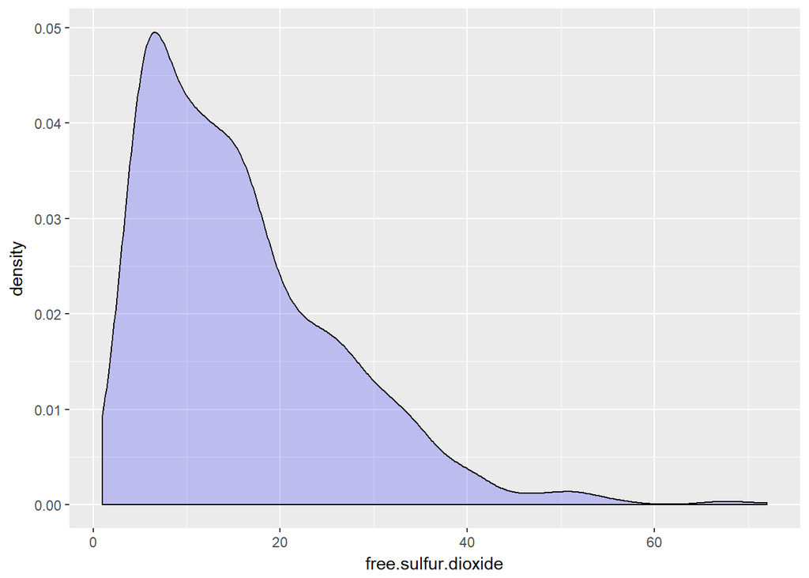

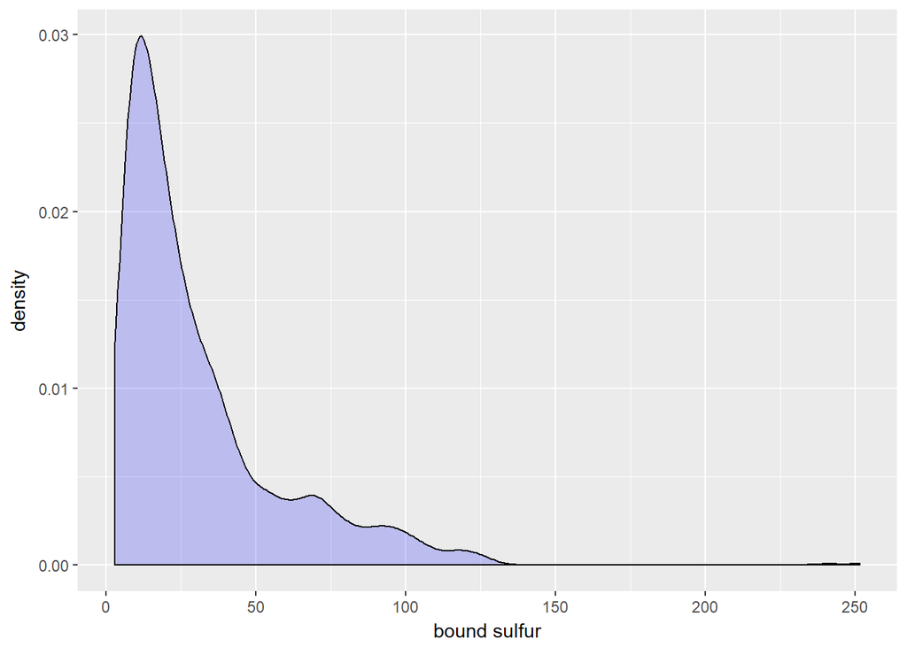

```
##    Min. 1st Qu.  Median    Mean 3rd Qu.    Max.
##    1.00    7.00   14.00   15.87   21.00   72.00
```

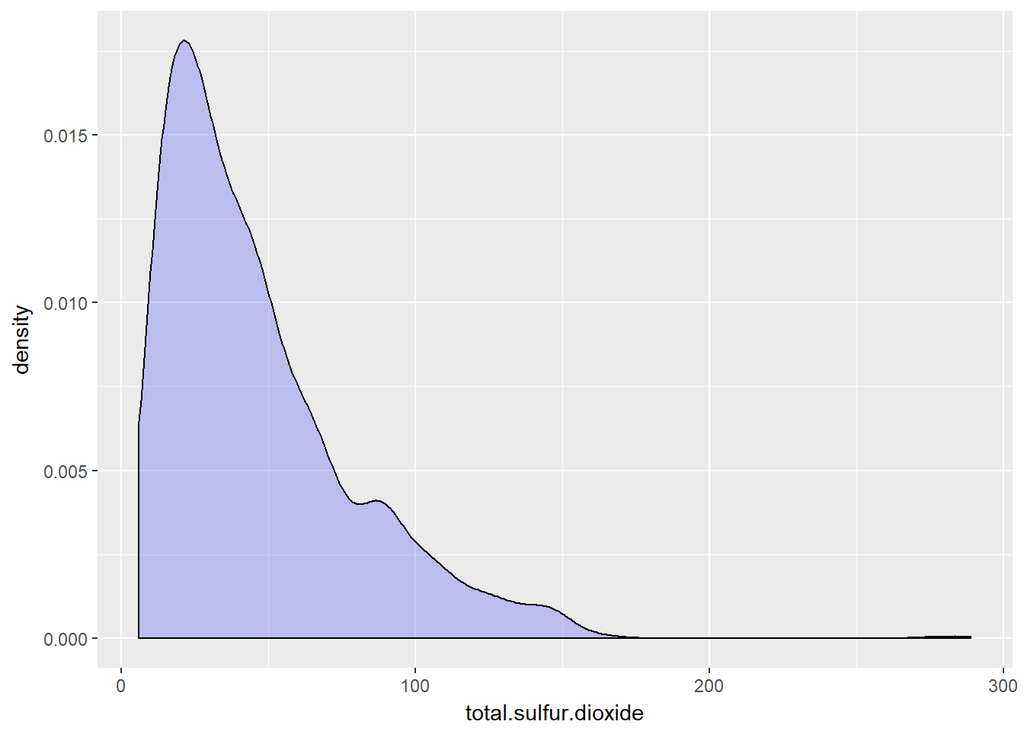

> According to the dataset description, the total.sulfur.dioxide is a superset of free.sulfur.dioxide and bound form of SO2. Most observations have small concentration of free or bound SO2. Only few observations have relatively higher concentrations of these materials which result in right skewed density plot.

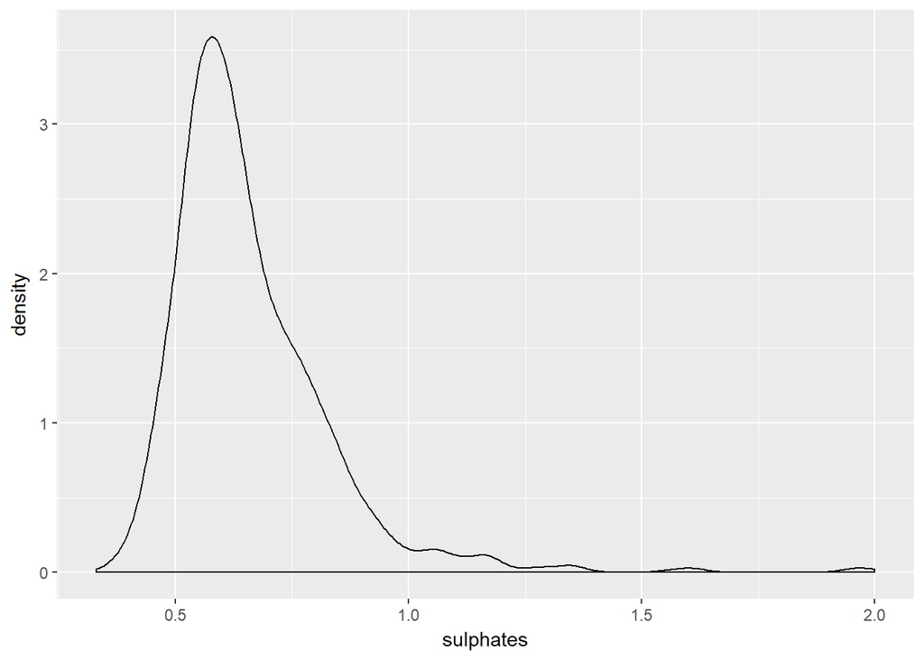

> The majority of observations have relatively small amount of Sulphate. Even at small amounts suphur can be antioxidant, anti aging and hence, it preserves the freshness of the wine. The density plot is right skewed. Sulphate contribute to SO2 substances so it will be interesting to study these materials together.

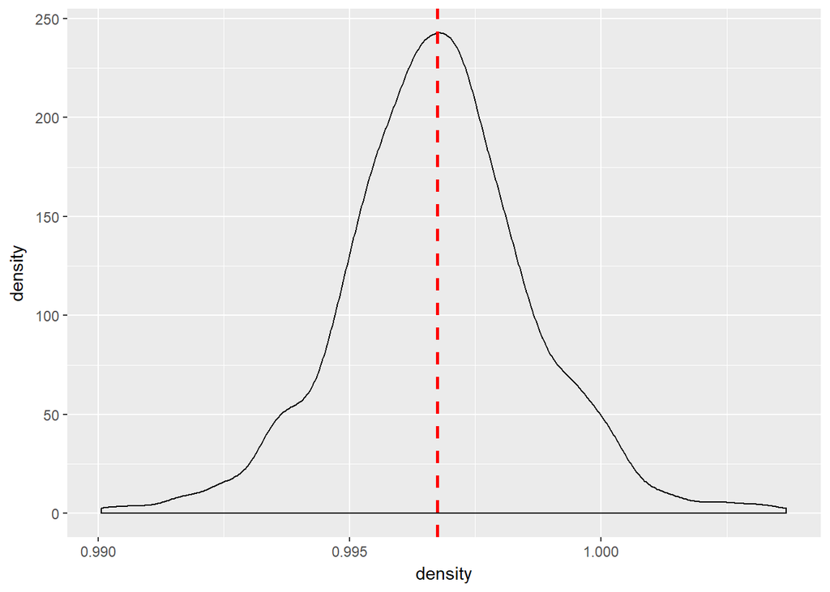

```
## [1] 0.9967467
```

```
## [1] 0.001887334
```

> Density is normally distibuted with center around the mean of 0.9967 and sd of 0.0019. Density depends on alcohol and sugar percentage so it should interesting to study these three variables together later in this report.

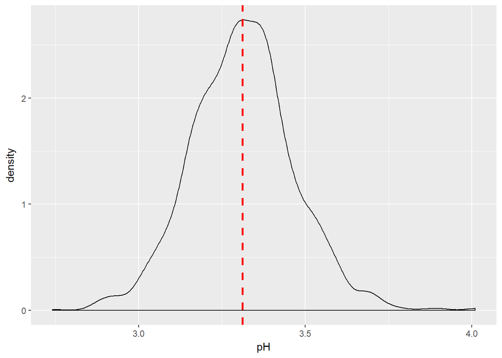

```
## [1] 3.311113
```

```
## [1] 0.1543865
```

```
##
##  4  5  6  7  8
##  1 13 10  3  2
```

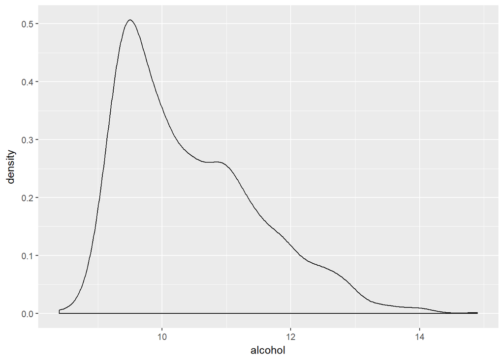

> I don’t think this is bimodal and it is probably a stretch to just call it right skewed. Most wines have about 9.5% alcohol, few observations have higher percentages of alcohol with a maximum of 15%.

```
## [1] "9.5"
```

```
##    Min. 1st Qu.  Median    Mean 3rd Qu.    Max.
##    8.40    9.50   10.20   10.42   11.10   14.90
```

# Univariate Analysis

> What is the structure of your dataset? The dataset has 1599 observations and 13 numerical variables.

> What is/are the main feature(s) of interest in your dataset? Quality is the main feature of interest.

> What other features in the dataset do you think will help support your  
> investigation into your feature(s) of interest? The main question to study is which factors affecting wine quality. In addition, I deduce some relationships between components when I read the dataset description. These relationships are (1) acidity and pH, (2) density vs alcohol and residual sugar, (3) sulphates and sulfur dioxides, (4) total sulphates and free sulphates. I look forward to investigating these relationships, either by verifying or debunking them. Furthermore, I read about red wine in http://winemakersacademy.com and would like to apply what I learnt there in this EDA.

> Did you create any new variables from existing variables in the dataset? Quality bucket to distiguish between high and low quality wines. Also, total.acidity which is the sum of citric and fixed acidity.

> Of the features you investigated, were there any unusual distributions?  
> Did you perform any operations on the data to tidy, adjust, or change the form  
> of the data? If so, why did you do this? Most of the relationships were right skewed with long or short tail. There are two normally distributed relationships, density and pH. Volatile.acidity has a bimodal distribution. Furthermore, I couldn’t find a pattern for citric acidity.

# Bivariate Plots Section

> I have 13 variables so I will start by plotting the correlation coefficient

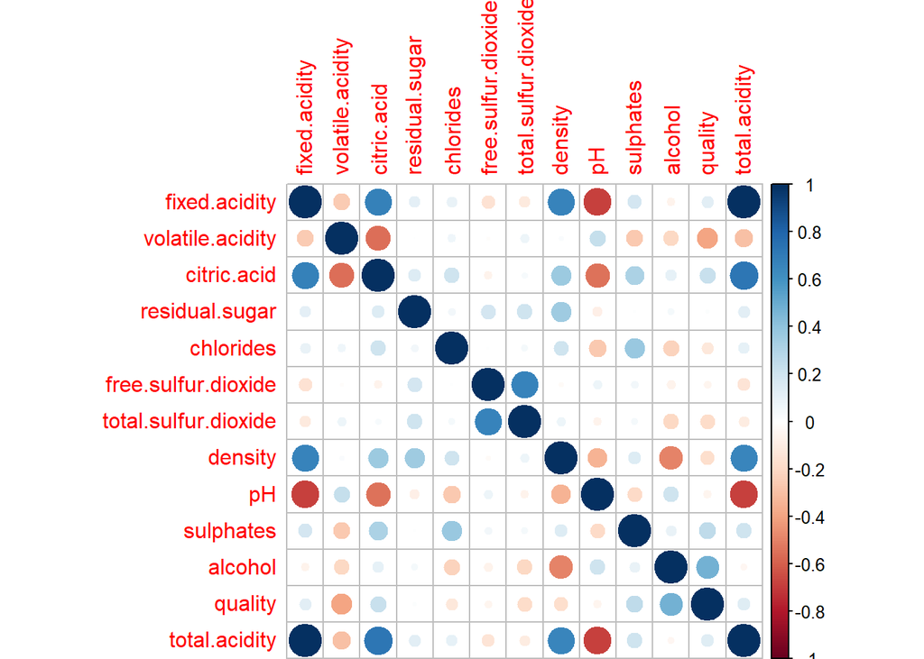

> From the plot above, I think it will be useful to look at the following relationships:

> fixed.acidity vs citric.acid, fixed.acidity vs pH (negative), volatile.acidity vs citric.acid (negative), citric.acid vs pH (negative)

> quality vs alcohol, quality vs sulphates, quality vs citric.acid, quality vs. fixed.acidity, quality vs volatile.acidity (negative)

> density vs fixed acidity, density vs alcohol (negative), density vs citric.acid, density vs residual sugar, density vs pH (negative)

### Acidity (fixed, volatile and citric).

> Recall pH is the measurement of strength of acidity, and acidity is a measurement of how much acid you have. Usually, the higher the amound of acid the smaller the pH. Therefore, it is expected to see linear relationship between pH and acidity. Volatile acids are not measured by pH though. Although volatile acids seem to have a positive relationship with pH in the correlation plot above, it is likely a fake relationship that is created by other factors.

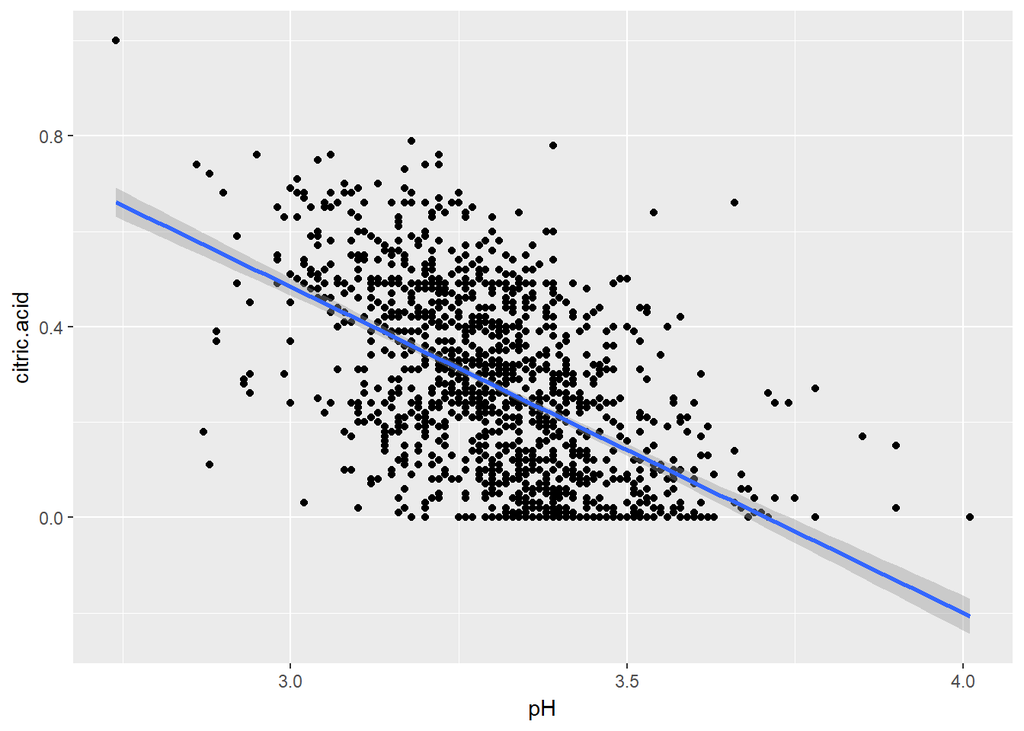

```
##
##  Pearson's product-moment correlation
##
## data:  df$pH and df$citric.acid
## t = -25.767, df = 1597, p-value < 2.2e-16
## alternative hypothesis: true correlation is not equal to 0
## 95 percent confidence interval:
##  -0.5756337 -0.5063336
## sample estimates:
##        cor
## -0.5419041
```

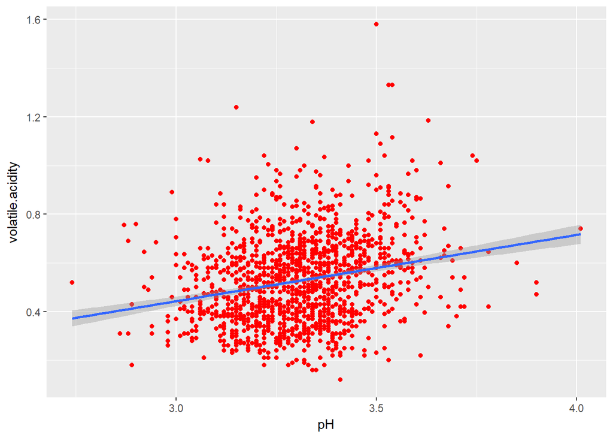

```
##
##  Pearson's product-moment correlation
##
## data:  df$pH and df$volatile.acidity
## t = 9.659, df = 1597, p-value < 2.2e-16
## alternative hypothesis: true correlation is not equal to 0
## 95 percent confidence interval:
##  0.1880823 0.2807254
## sample estimates:
##       cor
## 0.2349373
```

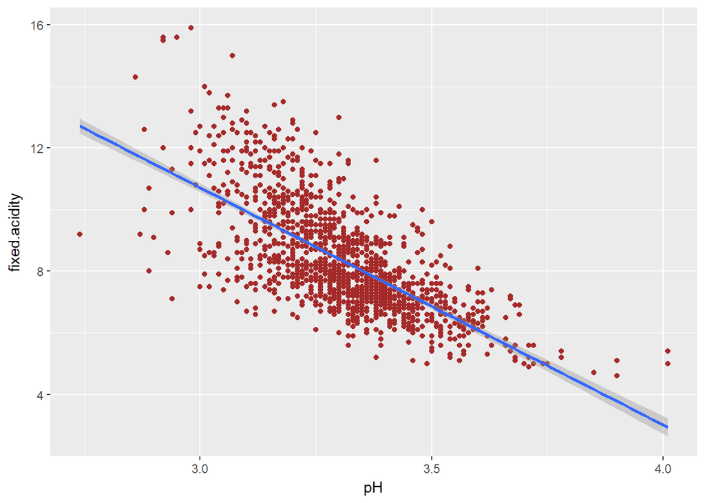

```
##
##  Pearson's product-moment correlation
##
## data:  df$pH and df$fixed.acidity
## t = -37.366, df = 1597, p-value < 2.2e-16
## alternative hypothesis: true correlation is not equal to 0
## 95 percent confidence interval:
##  -0.7082857 -0.6559174
## sample estimates:
##        cor
## -0.6829782
```

> In high concentrations, the fixed acids can give the wine tartaric taste. There is strong negative relationship between pH and fixed acidity. The pearson correlation coeficient is -0.68. Fixed acidity is very important in wine industry, it gives each wine its own characteristic. Fixed and citric acids are the two factors that contribute to pH in this dataset.

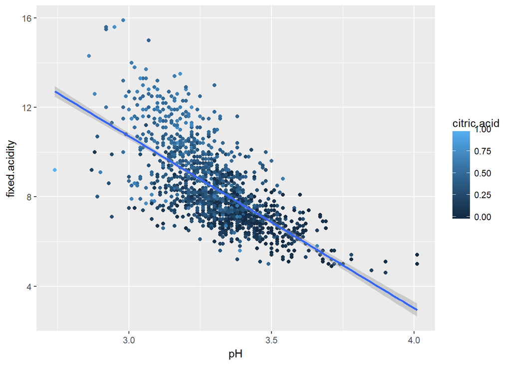

```
##
##  Pearson's product-moment correlation
##
## data:  df$pH and (df$fixed.acidity + df$citric.acid)
## t = -38.052, df = 1597, p-value < 2.2e-16
## alternative hypothesis: true correlation is not equal to 0
## 95 percent confidence interval:
##  -0.7144540 -0.6629746
## sample estimates:
##        cor
## -0.6895844
```

> The plot above shows that when you have high fixed and citric acids amounts the pH will be low and vice versa. The sum of these two substances have a - 0.69 correlation coefficient. Based on this analysis, I added a column of total acidity to the dataset, this variables is the sum of fixed and citric acids.

### Density

> The dataset description says that the main components of density is sugar and alcohol, I will test the accuracy of this statement.

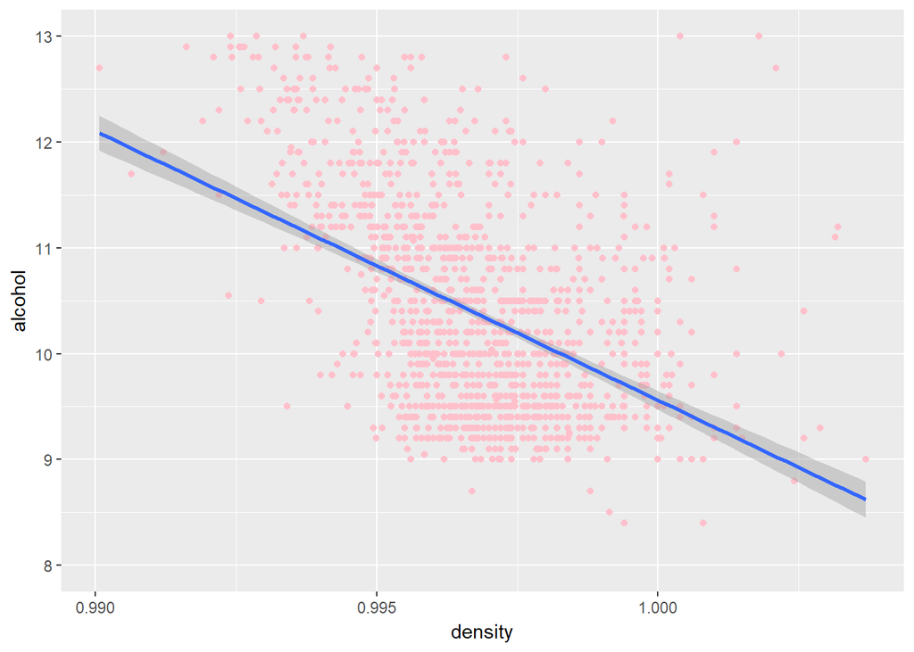

```
##
##  Pearson's product-moment correlation
##
## data:  df$density and df$alcohol
## t = -22.838, df = 1597, p-value < 2.2e-16
## alternative hypothesis: true correlation is not equal to 0
## 95 percent confidence interval:
##  -0.5322547 -0.4583061
## sample estimates:
##        cor
## -0.4961798
```

> There is a negative relationship with an R of -0.50 between density and alcohol.

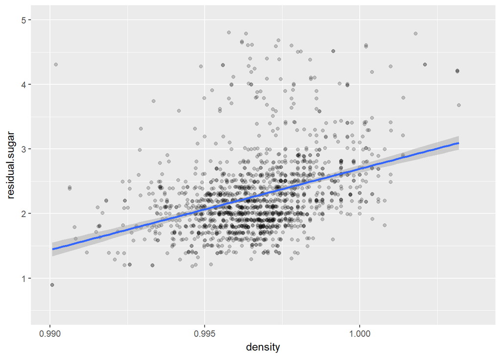

```
##
##  Pearson's product-moment correlation
##
## data:  df$density and df$residual.sugar
## t = 15.189, df = 1597, p-value < 2.2e-16
## alternative hypothesis: true correlation is not equal to 0
## 95 percent confidence interval:
##  0.3116908 0.3973835
## sample estimates:
##       cor
## 0.3552834
```

> There is a positive weak relationship with as R of 0.36 between density and residual.sugar.

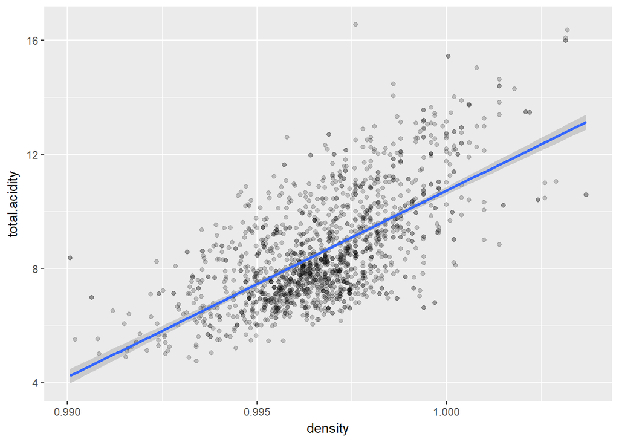

```
##
##  Pearson's product-moment correlation
##
## data:  df$density and df$total.acidity
## t = 34.862, df = 1597, p-value < 2.2e-16
## alternative hypothesis: true correlation is not equal to 0
## 95 percent confidence interval:
##  0.6286142 0.6843458
## sample estimates:
##      cor
## 0.657378
```

> There is a good positive relationship with an R of 0.66 between denstiy and total.acidity.

> I conclude that residual sugar doesn’t correlate much with density, rather alcohol and total acidity seems to be the major contributers. I think more statistical analysis are needed to determine if the relationship between density and total acidity is real or an artifact of other relationships, but I cannot see that by using my current tools

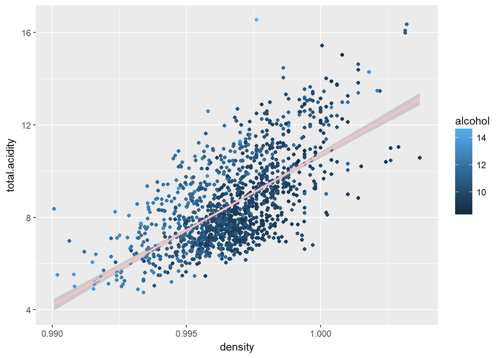

> This plot shows, again, the nice positive relationship between density, and total acidity and a negative one with alcohol.

### Quality

> Note that the lack of observations with quality of 3, 4, 7 and 8 makes it hard to make conclusions out of the plots below.

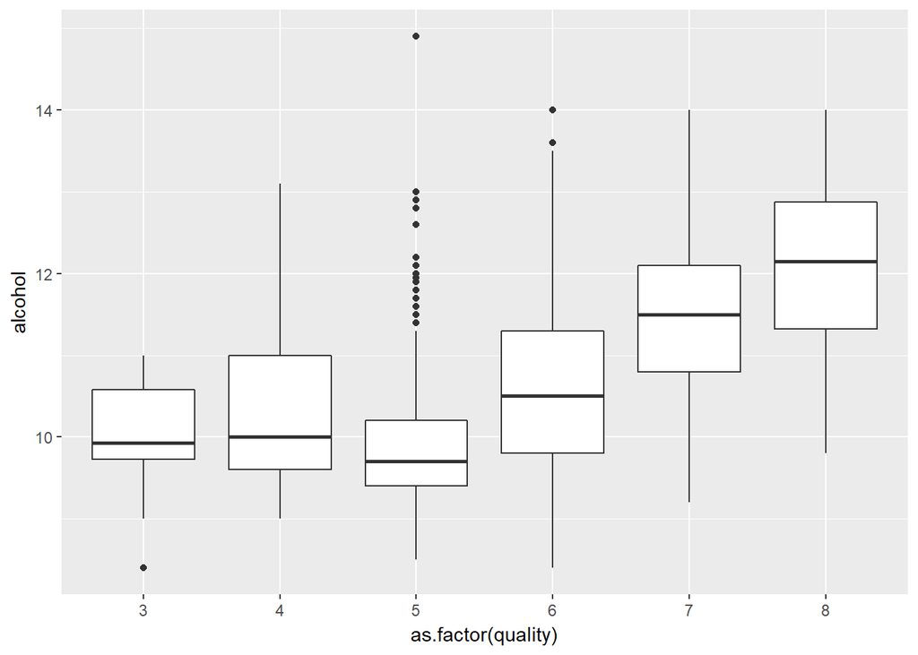

> Quality increases with alcohol, the boxplot shows this with the exception of quality 5 which has lower mean of alcohol with respect to quality of 4. Quality 5 also has a large number of outliers. There is a positive relationship between alcohol and the wine quality with R of 0.48.

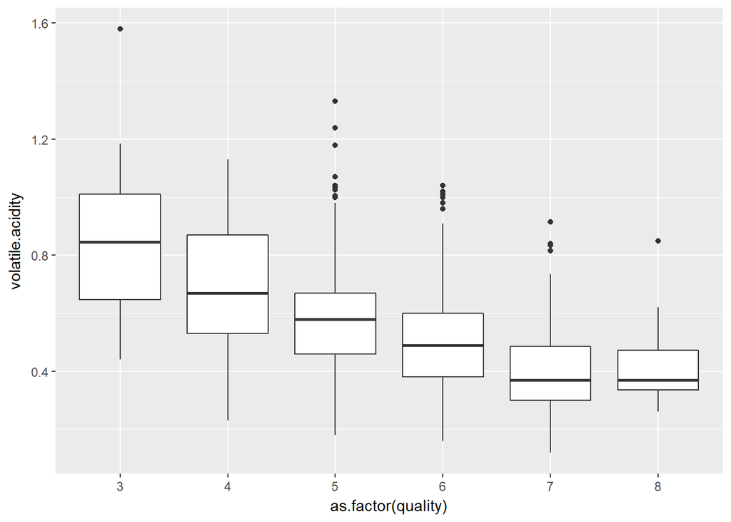

> Quality depends weakly on sulphates (R = 0.25), citric.acid (R = 0.23) and total.acidity (R = 0.17), as shown below.

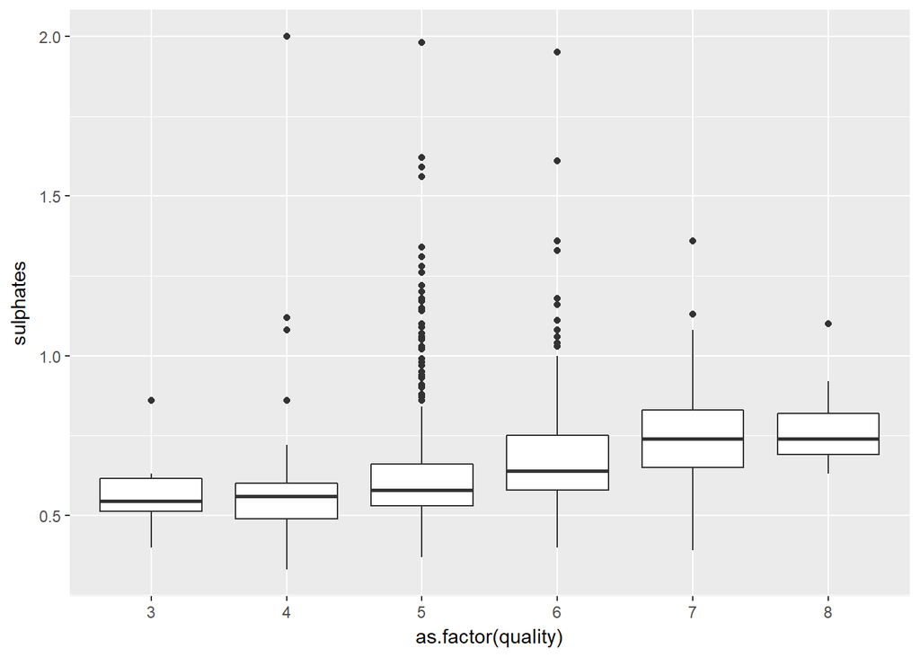

> This is a weak positive relationship with the quartiles (almost) increasing with quality and the mean of sulphates for each category also increases. The R value for this relationship is 0.25.

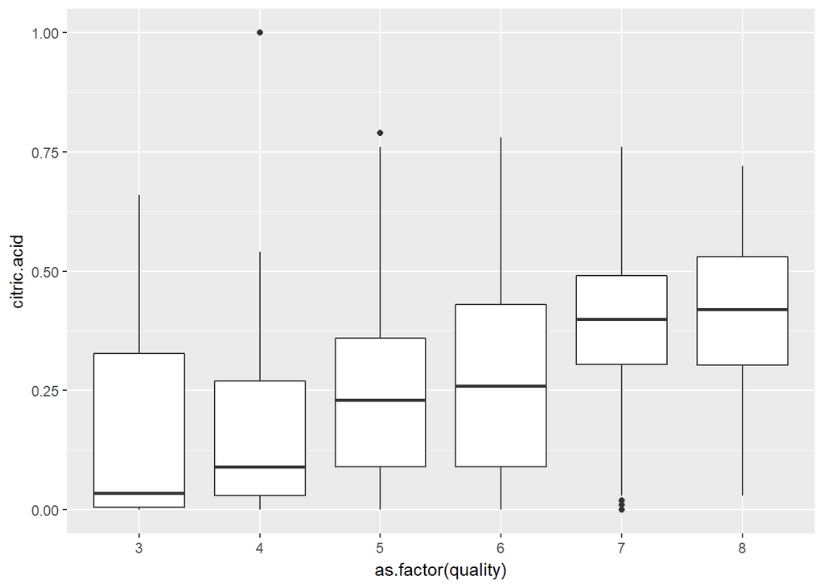

> Although we can see the positive relationship between citric acid and quality, the small number of observations in category 3 is making it hard to make conclusions because the huge quartile of category 3 is probably weakening the relationship between citric acid and quality. The R value is 0.23.

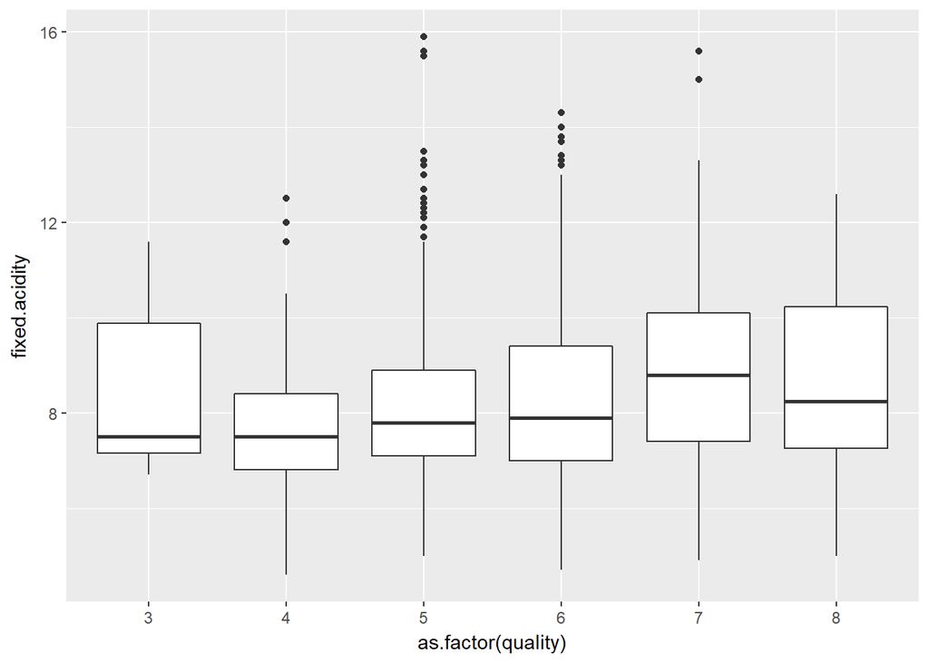

> Fixed acidity also has a weak relationship with quality, qualities of 3 and 8 and the too few observations is affecting the increasing trend. This relationship has an R value of 0.17.

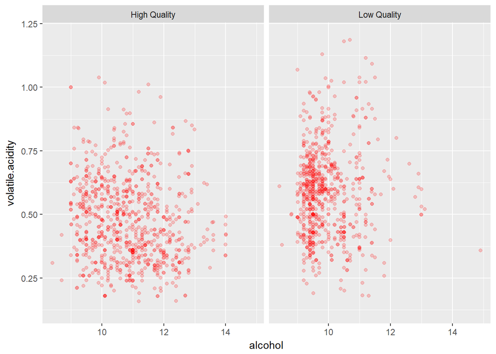

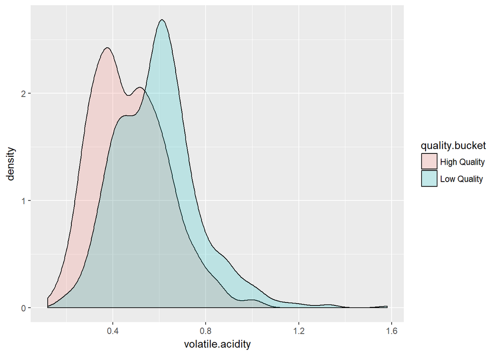

> The plots above show other views of the major two factors contributing to quality. The first plot shows the low quality win (<=5) vs high quality (> 5). I solved overplotting by adding a jitter. The weak relationships do not make it easy to view the relationship but one can notice that high quality has relatively smaller values of volatile acidity and higher numbers of alcohol percentages. Second plot is interesting because it “kind of” breaks down the bimodal density plot in volatile acidity, it turns out that the higher mod belongs to low quality wine.

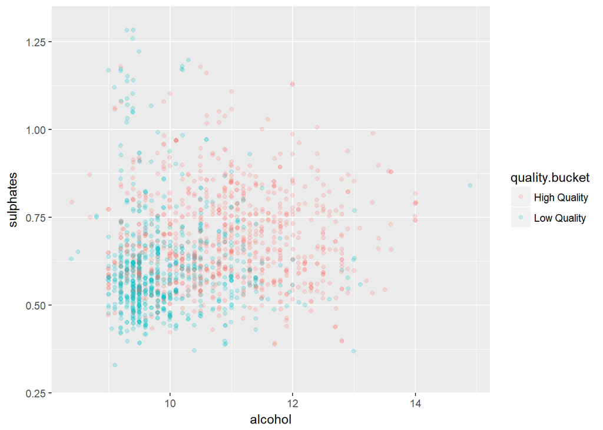

> Recall, that low quality in this plot refers to quality of less than or equal to 5, otherwise the wine is in the high category. It is interesting to see that low quality wine has smaller amount of alcohol and also smaller amounts of sulphates.

> Other potential relationships I will investigate next are: sulphates and chlorides, free, bound, total sulfur dioxide and sulphates.